# Identifying signature genes: psychENCODE Dataset

Chong Jin, Paul Little

2019-04-05

This file constructs the the reference matrix “tpm_signature_genes.rds” using psychENCODE single cell data.

# 1 Cells with high confidence cell type calls

We extract the signature genes from the adult single nucleus RNA-seq data produced by [@wang_comprehensive_2018], including adult using single-nucleus droplet-based sequencing (snDrop-seq) from PFC [@lake_integrative_2018].

```r
bio_packs = c("SingleCellExperiment","DropletUtils","biomaRt",
              "scater","scran","limma","org.Hs.eg.db")
source("https://bioconductor.org/biocLite.R")
for(pack1 in bio_packs){
  if( !pack1 %in% installed.packages()[,"Package"]){
    biocLite(pack1, suppressUpdates = TRUE)
  }
}

cran_packs = c("data.table","svd","Rtsne","stringi","irlba","venn")
for(pack1 in cran_packs){
  if( !pack1 %in% installed.packages()[,"Package"]){
    install.packages(pack1)
  }
}

library(data.table)
library(SingleCellExperiment)
# library(DropletUtils)
# library(biomaRt)
# library(scater)
# library(scran)
library(limma)
library(ggplot2)
library(venn)
```

First we add cell type labels by collapsing together the related cell types identified by the authors.

```r
work_dir = psychENCODE_dir = "~/psychENCODE_data"
sce = readRDS(file.path(psychENCODE_dir,"sce.rds"))
if (FALSE) {
  tpm(sce) = counts(sce)/rowData(sce)$gene_length
  tpm(sce) = (1e6)*t(t(tpm(sce))/colSums(tpm(sce)))
  logcounts(sce) = log2(1 + tpm(sce))
}
num_genes = nrow(sce)
```

```r
table(colData(sce)$part_cell_id)
```

```
##
##     Astro      Endo       Ex1       Ex2      Ex3e       Ex4      Ex5b
##      2801       139      5035      1427       587      1564      2644
##      Ex6a      Ex6b       Ex8       Ex9      In1a      In1b      In1c
##       318      1418       288       125       180       322       612
##       In3      In4a      In4b      In6a      In6b       In7       In8
##       596       245       611       272      1425       282      1306
## Microglia     Oligo       OPC       Per
##       300      2609      1240        39
```

```r
colData(sce)$cell_type = colData(sce)$part_cell_id
colData(sce)$cell_type[grep("In", colData(sce)$part_cell_id)] = "Inh"
colData(sce)$cell_type[grep("Ex", colData(sce)$part_cell_id)] = "Exc"
colData(sce)$cell_type[grep("Oligo", colData(sce)$part_cell_id)] = "Oligo"  # no change
colData(sce)$cell_type[grep("OPC", colData(sce)$part_cell_id)] = "OPC"  # no change
colData(sce)$cell_type[grep("Astro", colData(sce)$part_cell_id)] = "Astro"  # no change
colData(sce)$cell_type[grep("Microglia", colData(sce)$part_cell_id)] = "Micro"  #   no change
colData(sce)$cell_type[grep("Endo", colData(sce)$part_cell_id)] = "Endo"  #   no change
table(colData(sce)$cell_type)
```

```
##
## Astro  Endo   Exc   Inh Micro Oligo   OPC   Per
##  2801   139 13406  5851   300  2609  1240    39
```

We then select the subset of cells that are clusted with the cells of the same type.

```r
clusters    =  readRDS(file.path(psychENCODE_dir, "k25_50_pcs.rds"))

dim(sce)
```

```
## [1] 13376 26416
```

```r
dim(colData(sce))
```

```
## [1] 26416    39
```

```r
colData(sce)[1:2,1:5]
```

```
## DataFrame with 2 rows and 5 columns
##      sample_name part_cell_id is_cell_control total_features_by_counts
##      <character>  <character>       <logical>                <integer>
## Ex3e        Ex3e         Ex3e           FALSE                     4239
## Ex2          Ex2          Ex2           FALSE                     2881
##      log10_total_features_by_counts
##                           <numeric>
## Ex3e               3.62736585659273
## Ex2                3.45969397647797
```

```r
names(colData(sce))
```

```
##  [1] "sample_name"
##  [2] "part_cell_id"
##  [3] "is_cell_control"
##  [4] "total_features_by_counts"
##  [5] "log10_total_features_by_counts"
##  [6] "total_counts"
##  [7] "log10_total_counts"
##  [8] "pct_counts_in_top_50_features"
##  [9] "pct_counts_in_top_100_features"
## [10] "pct_counts_in_top_200_features"
## [11] "pct_counts_in_top_500_features"
## [12] "total_features_by_counts_endogenous"
## [13] "log10_total_features_by_counts_endogenous"
## [14] "total_counts_endogenous"
## [15] "log10_total_counts_endogenous"
```

[output cut: 24 more lines]

```r
table(colData(sce)$donor)
```

```
## < table of extent 0 >
```

```r
dim(rowData(sce))
```

```
## [1] 13376    19
```

```r
rowData(sce)[1:2,]
```

```
## DataFrame with 2 rows and 19 columns
##       hgnc_symbol ensembl_gene_id external_gene_name chromosome_name
##       <character>     <character>        <character>     <character>
## ABCA7       ABCA7 ENSG00000064687              ABCA7              19
## AAMDC       AAMDC ENSG00000087884              AAMDC              11
##       start_position end_position  strand_n
##            <integer>    <integer> <integer>
## ABCA7        1040101      1065572         1
## AAMDC       77821109     77918432         1
##                                                                                description
##                                                                                <character>
## ABCA7           ATP binding cassette subfamily A member 7 [Source:HGNC Symbol;Acc:HGNC:37]
## AAMDC adipogenesis associated Mth938 domain containing [Source:HGNC Symbol;Acc:HGNC:30205]
##       percentage_gene_gc_content   gene_biotype gene_length
##                        <numeric>    <character>   <integer>
## ABCA7                      60.49 protein_coding        8367
## AAMDC                      41.82 protein_coding        1943
##       is_feature_control is_feature_control_Ri        mean_counts
##                <logical>             <logical>          <numeric>
## ABCA7              FALSE                 FALSE 0.0698599153655333
## AAMDC              FALSE                 FALSE   0.12498175981322
##        log10_mean_counts n_cells_by_counts pct_dropout_by_counts
##                <numeric>         <integer>             <numeric>
## ABCA7 0.0293269160342217              1752      93.6086385524588
## AAMDC 0.0511454809569934              3005      89.0376477455129
##       total_counts log10_total_counts
##          <integer>          <numeric>
## ABCA7         1915   3.28239550474253
## AAMDC         3426   3.53491410442987
```

```r
clusters = data.frame(KM25=clusters$cluster)
clusters$cell_type = colData(sce)$cell_type

opt_clust = paste0("KM",25) # our clustering results differ slightly
t1 = table(clusters[,opt_clust], clusters$cell_type)
t1
```

```
##
##      Astro Endo  Exc  Inh Micro Oligo  OPC  Per
##   1      7    2 1116   18     5    10    2    1
##   2      0    8 1478   17     7     1   17    0
##   3      3    1   17 1157     0     1    1    0
##   4      2    0    3  246     0     0    0    0
##   5      0   13 2373   23    20     1   23    0
##   6     23   12    0    3    32   749   25    0
##   7      2    5 1040    2     0     2    5    0
##   8      3    1  767    7     3     9   10    0
##   9    301    3    0    0     4     0    0    0
##   10     2    7 1893   13     5     0   10    0
##   11     4    0 1388   19     9     6    3    1
##   12     0    1 1010    7     3     4   12    0
##   13    16   41  110  487   115    13   26   25
##   14     9    2  225    5     9    70    4    0
##   15     1    1    0  588     0     1    0    0
##   16   957    3    1    0     9     0    0    0
##   17    10    0    0    0     2     0 1046    0
##   18   631    0    2    0     3     0    1    1
##   19    23    6    5    7    29  1676   18    2
##   20     0    0  264    1     0     0    1    0
##   21   758    7    4    0    14     0    0    0
##   22    45   25 1689  344    31    64   31    9
##   23     1    0    1 1077     0     1    0    0
##   24     0    0    0  534     0     0    0    0
##   25     3    1   20 1296     0     1    5    0
```

```r
# remove cluster 15 & 23 since they belong to multiple clusters
t1[c(15,23), ] = 0

clusts = apply(t1, 2, function(v){union(which.max(v), which(v > 100))})
clusts
```

```
## $Astro
## [1] 16  9 18 21
##
## $Endo
## [1] 13
##
## $Exc
##  [1]  5  1  2  7  8 10 11 12 13 14 20 22
##
## $Inh
## [1] 25  3  4 13 22 24
##
## $Micro
## [1] 13
##
## $Oligo
## [1] 19  6
##
## $OPC
## [1] 17
##
## $Per
## [1] 13
```

```r
cell_types = setdiff(unique(clusters$cell_type), "unknown")
cell_types
```

```
## [1] "Exc"   "Inh"   "Oligo" "Astro" "OPC"   "Endo"  "Micro" NA      "Per"
```

```r
w2kp = NULL

for(ct1 in cell_types){
    # ct1 = celltypes[1]
    ct.cond    = clusters$cell_type == ct1
    clust.cond = clusters[,opt_clust] %in% clusts[[ct1]]
    # Intersect previous clustering result with ours
    w2kp = c(w2kp, which(ct.cond & clust.cond))
}
length(w2kp)
```

```
## [1] 23716
```

```r
dim(sce)
```

```
## [1] 13376 26416
```

```r
sce = sce[,w2kp]
dim(sce)
```

```
## [1] 13376 23716
```

# 2 Differential expression using MAST

Finally we use `MAST` to select differentially expressed genes using code provided by Paul Little.

```r
# source(file.path(repo_dir,"SOURCE.R"))
if( !("BiocManager" %in% installed.packages()[,"Package"]) ){
    install.packages("BiocManager",repos = "https://mirrors.nics.utk.edu/cran/")
}
if( !("MAST" %in% installed.packages()[,"Package"]) ){
    # MAST = Model-based Analysis of Single Cell Transcriptomics
    BiocManager::install("MAST")
}
library(ggplot2)
library(data.table)
```

```r
name_change = function(dat,orig_name,new_name){
        index = which(names(dat) == orig_name)
        if( length(index) > 0 ){
                names(dat)[index] = new_name
        }
        dat
}


MAST_DEgenes = function(work_dir,num_genes=NULL,sce_obj,one_cell_type,fdr_thres=1e-3,logFC_thres=log(2)){

    if(FALSE){
        work_dir = psychENCODE_dir
        num_genes = 100
        sce_obj = sce
        one_cell_type = c("Astro","Exc","Inh","Micro","Oligo","OPC")[1]
        fdr_thres = 1e-3
        logFC_thres = log(2)
    }

    # Subset Genes and make SingleCellAssay object
    if( is.null(num_genes) ){
        num_genes = nrow(sce_obj)
    }
    sca = MAST::SceToSingleCellAssay(sce = sce_obj[seq(num_genes),])

    # Calculate CDS
    colData(sca)$cngeneson = scale(colSums(logcounts(sca) > 0))

    # Calculate Group
    # one_cell_type = "Astro"
    ref_group = paste0("not_",one_cell_type)
    colData(sca)$Group = ifelse(colData(sca)$cell_type == one_cell_type,
        one_cell_type,ref_group)
    colData(sca)$Group = factor(colData(sca)$Group,
        levels = c(ref_group,one_cell_type))

    # zlm analysis: Model log-transformed expression as
    #   function of clustered cell type and num detected genes
    zlm_fn = file.path(work_dir,paste0("zlm",
        "_nG",num_genes,
        "_cell",one_cell_type,
        ".rds"))
    if( !file.exists(zlm_fn) ){
        print(date())
        zlm_output = MAST::zlm(formula = ~ Group + cngeneson,sca = sca)
        print(date())
        cat("Saving image ...\n")
        saveRDS(zlm_output,zlm_fn)
    }
    cat("Reading in image ...\n")
    zlm_output = readRDS(zlm_fn)
    # show(zlm_output)

    # Perform LRT of one cell_type against all others
    cat("Running LRT by excluding the cell_type covariate ...\n")
    print(date())
    ssc = MAST::summary(object = zlm_output,
        doLRT = paste0("Group",one_cell_type))
    print(date())

    ssc_fn = file.path(work_dir,paste0("ssc",
        "_nG",num_genes,
        "_cell",one_cell_type,
        ".rds"))
    saveRDS(ssc, ssc_fn)

    ssd0 = data.frame(ssc$datatable, stringsAsFactors = FALSE)
    ssd = ssd0[which(ssd0$component == "H"),]
    ssd = name_change(ssd,"Pr..Chisq.","pvalue")
    ssd = name_change(ssd,"primerid","gene")
    ssd = ssd[,c("gene","pvalue")]
    tmp_index = which(ssd0$component == "logFC"
                    & ssd0$contrast == paste0("Group",one_cell_type))
    ssd$logFC = ssd0$coef[tmp_index]
    ssd$z = ssd0$z[tmp_index]
    ssd = ssd[which(!is.na(ssd$logFC)),]
    ssd$FDR_qvalue = p.adjust(p = ssd$pvalue,method = "fdr")
    ssd = ssd[order(ssd$FDR_qvalue),]
    # Plot
    # smart_hist(ssd$FDR_qvalue,breaks=40,xlab="FDR",main="")
    # smart_hist(ssd$logFC,breaks=40)
    # plot(ssd[,c("FDR_qvalue","logFC")],pch=16,col=rgb(0,0,0,0.5))
    # dev.off()

    # filtering before generating ssd files -- do not use now
    # ssd = ssd[which(ssd$FDR_qvalue < fdr_thres
    #               & ssd$logFC > logFC_thres),]

    # dim(ssd); smart_table(ssd$logFC > 0); ssd[1:20,]
    ssd = data.frame(cell_type=one_cell_type,ssd,stringsAsFactors = FALSE)

    ssd_fn = file.path(work_dir,paste0("ssd",
        "_nG",num_genes,
        "_cell",one_cell_type,
        ".rds"))
    cat(paste0("Saving image in ",ssd_fn," ...\n"))
    saveRDS(ssd,ssd_fn)

    return(NULL)
}
```

```r
# Subset cell_types with enough cells: Exclude Endo
table(colData(sce)$cell_type, useNA="ifany")
```

```
##
## Astro  Endo   Exc   Inh Micro Oligo   OPC   Per
##  2647    41 13353  4064   115  2425  1046    25
```

```r
sce = sce[, !(colData(sce)$cell_type %in% c("Endo", "Per"))]
table(colData(sce)$cell_type, useNA="ifany")
```

```
##
## Astro   Exc   Inh Micro Oligo   OPC
##  2647 13353  4064   115  2425  1046
```

```r
dim(sce)
```

```
## [1] 13376 23650
```

```r
# Get cell type specific marker genes
# one_ct = "blah_one_ct"
cts = c("Astro", "Exc", "Inh", "Micro", "Oligo", "OPC")

# one_ct = "Astro"
# one_ct = "Exc"
# one_ct = "Inh"
# one_ct = "Micro"
# one_ct = "Oligo"
# one_ct = "OPC"

# Will need 64 GB of memory.
if (FALSE) {
  for (one_ct in cts) {
    MAST_DEgenes(work_dir = psychENCODE_dir,
            num_genes = nrow(sce),
            # num_genes = 100,
            sce_obj = sce,
            one_cell_type = one_ct,
            fdr_thres = 1e-3,
            logFC_thres = log(2))
    gc()
  }
}
```

# 3 Select signature genes

The following code chuck is the new version which gives the logFC for every gene that we use now.

```r
source("~/scRNAseq_pipelines/SOURCE.R")

gene_anno = as.data.frame(rowData(sce)[,
    c("ensembl_gene_id","external_gene_name","chromosome_name","start_position","end_position")])
gene_anno = dplyr::rename(gene_anno, gene=external_gene_name)
gene_anno$prop_express = as.numeric(apply(assay(sce),1,function(xx) mean(xx > 0)))

# For each cell type, gather logFC, qvalues, prop cells expressed in genes
cell_types = c("Astro","Exc","Inh","Micro","Oligo","OPC")
for(ct in cell_types){
    # ct = "Astro"
    cat(paste0(ct," "))
    tmp_df = readRDS(file.path(psychENCODE_dir,paste0("ssd_nG",num_genes,"_cell",ct,".rds")))
    tmp_df = tmp_df[,c("gene","pvalue","logFC","FDR_qvalue")]
    names(tmp_df)[-1] = paste0(names(tmp_df)[-1],".",ct)
    # Calculating proportion of cells expressed in a gene and cell_type
    bb = apply(assay(sce[,colData(sce)$cell_type %in% ct]),1,
        function(xx) mean(xx > 0))
    bb = data.frame(gene = names(bb),prop_express = as.numeric(bb), stringsAsFactors = FALSE)
    names(bb)[2] = paste0(names(bb)[2],".",ct)
    bb = merge(bb,tmp_df,by="gene",all.x=TRUE,sort=FALSE)
    all(bb$gene == gene_anno$gene)
    bb = bb[match(gene_anno$gene,bb$gene),]
    all(bb$gene == gene_anno$gene)
    gene_anno = cbind(gene_anno, bb[,names(bb) != "gene"])
    rm(tmp_df,bb)
}
```

```
## Astro Exc Inh Micro Oligo OPC
```

```r
dim(gene_anno)
```

```
## [1] 13376    30
```

```r
head(gene_anno)
```

```
##            ensembl_gene_id       gene chromosome_name start_position
## ABCA7      ENSG00000064687      ABCA7              19        1040101
## AAMDC      ENSG00000087884      AAMDC              11       77821109
## AC116050.1 ENSG00000278131 AC116050.1               2       91589494
## ABHD13     ENSG00000139826     ABHD13              13      108218379
## AC011754.1 ENSG00000224879 AC011754.1               2       79158374
## AC016716.2 ENSG00000224731 AC016716.2               2       80028012
##            end_position prop_express prop_express.Astro pvalue.Astro
## ABCA7           1065572   0.06646934        0.013600302 8.492638e-15
## AAMDC          77918432   0.11095137        0.100868908 1.126819e-17
## AC116050.1     91621421   0.09086681        0.024933887 2.117553e-04
## ABHD13        108234255   0.07205074        0.021156026 2.109030e-05
## AC011754.1     79185523   0.01437632        0.001133359 1.852648e-02
## AC016716.2     80030551   0.17213531        0.340763128 0.000000e+00
##            logFC.Astro FDR_qvalue.Astro prop_express.Exc   pvalue.Exc
## ABCA7      -0.31315585     3.063768e-14       0.09578372 4.860885e-20
## AAMDC       0.68206209     4.521483e-17       0.13120647 3.581015e-19
## AC116050.1 -0.09674384     3.893151e-04       0.13218003 1.259850e-02
## ABHD13     -0.21368375     4.311608e-05       0.09967797 1.034635e-03
## AC011754.1 -0.06205158     2.631788e-02       0.02433910 1.789199e-13
## AC016716.2  5.12837584     0.000000e+00       0.20152775 1.847429e-57
##              logFC.Exc FDR_qvalue.Exc prop_express.Inh   pvalue.Inh
## ABCA7       0.25728040   1.807595e-19      0.056102362 5.177762e-01
## AAMDC      -0.41484359   1.290400e-18      0.084645669 1.117051e-05
## AC116050.1  0.05838309   1.831314e-02      0.066190945 2.220767e-01
## ABHD13      0.10408705   1.699114e-03      0.059301181 2.809419e-03
## AC011754.1  0.09927447   5.280742e-13      0.000984252 2.287807e-11
## AC016716.2 -0.92177568   1.443412e-56      0.092519685 5.872741e-33
##              logFC.Inh FDR_qvalue.Inh prop_express.Micro pvalue.Micro
## ABCA7       0.02495653   5.325306e-01        0.008695652 1.614757e-01
## AAMDC      -0.06571287   2.188295e-05        0.017391304 1.086062e-01
## AC116050.1  0.05839068   2.385942e-01        0.008695652 6.714744e-01
## ABHD13      0.03647508   3.956911e-03        0.043478261 6.379307e-07
## AC011754.1 -0.08683190   7.774823e-11        0.000000000           NA
## AC016716.2 -0.76210249   4.735008e-32        0.000000000           NA
##            logFC.Micro FDR_qvalue.Micro prop_express.Oligo pvalue.Oligo
## ABCA7       -0.2485103     1.913046e-01        0.008247423 8.413381e-17
## AAMDC       -0.4547845     1.335680e-01        0.070515464 2.789003e-21
## AC116050.1  -0.2081629     7.039905e-01        0.006597938 2.154922e-08
## ABHD13       0.4819025     4.813047e-06        0.014020619 5.000971e-06
## AC011754.1          NA               NA        0.002474227 9.825871e-01
## AC016716.2          NA               NA        0.003711340 1.225264e-69
##             logFC.Oligo FDR_qvalue.Oligo prop_express.OPC   pvalue.OPC
## ABCA7      -0.337313224     2.174314e-16      0.007648184 4.165560e-09
## AAMDC       0.548905849     9.413591e-21      0.084130019 4.601513e-03
## AC116050.1 -0.385063737     3.332905e-08      0.030592734 1.830027e-02
## ABHD13     -0.242493322     6.653301e-06      0.035372849 5.967456e-01
## AC011754.1 -0.005678005     9.828086e-01      0.001912046 4.704442e-01
## AC016716.2 -1.779454541     1.644225e-68      0.088910134 1.528559e-01
##               logFC.OPC FDR_qvalue.OPC
## ABCA7      -0.355438918   2.797507e-08
## AAMDC       0.378110673   1.234244e-02
## AC116050.1  0.020034934   4.111226e-02
## ABHD13      0.007571271   6.831687e-01
## AC011754.1 -0.040153208   5.720083e-01
## AC016716.2 -0.090172849   2.394437e-01
```

```r
# Output
saveRDS(gene_anno, file.path(psychENCODE_dir,"DE_gene_anno.rds"))
```

We will need to pick top 100 genes for each cell type, and then try to calculate their cell type-specific TPMs.

```r
# how many genes will pass the threshold?
gene_anno = readRDS(file.path(psychENCODE_dir,"DE_gene_anno.rds"))
cell_types = c("Astro","Exc","Inh","Micro","Oligo","OPC")
fdr_thres = 1e-3
logFC_thres = log(2)
for(ct in cell_types){
  cat(sprintf("%s genes matching fdr and logFC threshold:", ct))
  filtered_count = nrow(gene_anno[which(gene_anno[paste0("FDR_qvalue.", ct)] < fdr_thres
                                & gene_anno[paste0("logFC.", ct)] > logFC_thres),])
  cat(sprintf(" %d\n", filtered_count))
}
```

```
## Astro genes matching fdr and logFC threshold: 1296
## Exc genes matching fdr and logFC threshold: 863
## Inh genes matching fdr and logFC threshold: 678
## Micro genes matching fdr and logFC threshold: 581
## Oligo genes matching fdr and logFC threshold: 844
## OPC genes matching fdr and logFC threshold: 868
```

```r
# Okay, for each cell type we will pick top 100 genes by logFC rank
# after the fdr threshold has been met:
# (will need to use the intersection with the gene list from MTG dataset later)
count_per_each_cell_type = 100
gene_anno_by_cell_type = list()
for(ct in cell_types){
  gene_anno_by_cell_type[[ct]] =
      gene_anno[which(gene_anno[paste0("FDR_qvalue.", ct)] < fdr_thres
                              & gene_anno[paste0("logFC.", ct)] > logFC_thres),]
}

# Venn plot
pdf(file.path(psychENCODE_dir,"venn.pdf"),width=8,height=8)
venn(x = sapply(gene_anno_by_cell_type, function(x) x$ensembl_gene_id),
     ilabels = TRUE,zcolor = "style")
dev.off()
```

```r
# remove genes that appear in more than one cell type:
gene_anno_by_cell_type_dedup = list()
gene_appearance_counts = table(do.call(rbind, gene_anno_by_cell_type)$ensembl_gene_id)
gene_appeared_once = names(gene_appearance_counts)[gene_appearance_counts == 1]
for(ct in cell_types){
  gene_anno_by_cell_type_dedup[[ct]] = gene_anno_by_cell_type[[ct]][
      gene_anno_by_cell_type[[ct]]$ensembl_gene_id %in% gene_appeared_once, ]
  gene_anno_by_cell_type_dedup[[ct]] = gene_anno_by_cell_type_dedup[[ct]][
      order(-gene_anno_by_cell_type_dedup[[ct]][,paste0("logFC.", ct)]), ]
  cat(sprintf("%s genes after filtering that appear only once:", ct))
  cat(sprintf(" %d\n", nrow(gene_anno_by_cell_type_dedup[[ct]])))
}
```

```
## Astro genes after filtering that appear only once: 821
## Exc genes after filtering that appear only once: 615
## Inh genes after filtering that appear only once: 388
## Micro genes after filtering that appear only once: 339
## Oligo genes after filtering that appear only once: 496
## OPC genes after filtering that appear only once: 307
```

```r
# only retain the top 100 or some other number per cell type -- this is the final gene list:
ct_anno = list()
for(ct in cell_types){
  ct_anno[[ct]] = gene_anno_by_cell_type_dedup[[ct]][1:count_per_each_cell_type, ]
}
saveRDS(ct_anno, file.path(psychENCODE_dir,"DE_ct_anno.rds"))
```

# 4 Obtain TPM of signature genes

```r
# calculate total read count and then TPM for every cell type:
table(colData(sce)$cell_type)
```

```
##
## Astro   Exc   Inh Micro Oligo   OPC
##  2647 13353  4064   115  2425  1046
```

```r
ct_counts = matrix(nrow=nrow(sce), ncol=length(cell_types))
colnames(ct_counts) = cell_types
rownames(ct_counts) = rownames(sce)
for(ct in cell_types){
  ct_counts[,ct] = rowSums(counts(sce)[, colData(sce)$cell_type == ct])
}
dim(ct_counts)
```

```
## [1] 13376     6
```

```r
ct_tpm = ct_counts/rowData(sce)$gene_length
ct_tpm = (1e6)*t(t(ct_tpm)/colSums(ct_tpm))
tpm_signature_genes = ct_tpm[do.call(rbind, ct_anno)$gene, ]
# change the row names to ensembl gene id for better matching in downstream:
rownames(tpm_signature_genes) = gene_anno[rownames(tpm_signature_genes), "ensembl_gene_id"]
dim(tpm_signature_genes)
```

```
## [1] 600   6
```

```r
saveRDS(tpm_signature_genes, file.path(psychENCODE_dir,"tpm_signature_genes.rds"))
```

# 5 Obtain variance of log-transformed TPM from single cell data

Obviously, we only have single cell data and we would not be able to obtain across-sample variance, but we can still obtain variance estimates to use in ICeDT based on variance on single cell level restricted to each high-confidence cell types.

```r
library(scran)
```

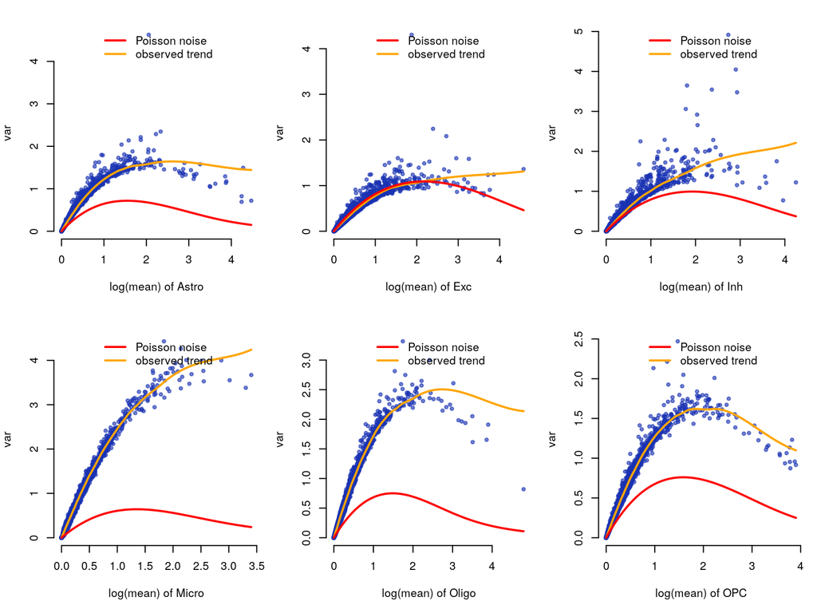

```r
par(mfrow=c(2,3), mar=c(5,4,2,1), bty="n")
dec_by_cell_type = list()

for (ct in cell_types) {

  sce_group_by_cell_type = sce[, colData(sce)$cell_type == ct]

  sce_group_by_cell_type = computeSumFactors(sce_group_by_cell_type, min.mean=0.1)

  new_trend = makeTechTrend(x=sce_group_by_cell_type)
  fit = trendVar(sce_group_by_cell_type, use.spikes=FALSE, loess.args=list(span=0.05))

  plot(fit$mean, fit$var, pch=20, col=rgb(0.1,0.2,0.7,0.6),
       xlab=paste("log(mean) of", ct), ylab="var")
  curve(fit$trend(x), col="orange", lwd=2, add=TRUE)
  curve(new_trend(x), col="red", lwd=2, add=TRUE)
  legend("top", legend=c("Poisson noise", "observed trend"),
         lty=1, lwd=2, col=c("red", "orange"), bty="n")

  fit$trend = new_trend

  dec     = decomposeVar(fit=fit)

  dec_by_cell_type[[ct]] = dec
}
```

```r
# TODO: do trendVar() after separating cells into cell types
# We assume that the total variance obtained here can be used in ICeDT to
# as weights to do deconvolution
# (since the curve resembles the variance-mean relation we see elsewhere,
#  e.g. DESeq2 paper.)
saveRDS(dec_by_cell_type, file.path(psychENCODE_dir,"psychENCODE_decomposeVar.rds"))
```

```r
var_signature_genes = tpm_signature_genes
var_signature_genes[] = NA
for (ct in cell_types) {
  rownames(dec_by_cell_type[[ct]]) = rowData(sce)$ensembl_gene_id
  var_signature_genes[,ct] = dec_by_cell_type[[ct]][rownames(tpm_signature_genes), "total"]
}
dim(var_signature_genes)
```

```
## [1] 600   6
```

```r
saveRDS(var_signature_genes, file.path(psychENCODE_dir,"var_signature_genes.rds"))
```